# **Predictive Modeling Using Simple Linear Regression utilizing the Tips Dataset**

### **1. Data Loading and Statistical Analysis**

This first code block primarily focuses on ensuring that the necessary scripts from the library, as well as the dataset are imported and loaded properly which are important in describing as well as indentifying the relationship between the variables.

- **Purpose of the code**:
  - The script imports `pandas` for data table management, `seaborn` for statistical visualization, and `matplotlib` for generating charts.
  - In addition it also loads the "tips" dataset, which contains information about restaurant bills and tip amounts, to serve as the primary data source.
  - It also utilizes `.info()`, `.head()`, and `.describe()` to review column types, view sample rows, and calculate statistical averages such as mean and standard deviation.
  - Then proceed with calculating the Pearson correlation coefficient to measure the numerical relationship between the total bill and the tip.
  - It also generates a scatter plot with a red regression line to provide a visual exploration of the data trend.
  - Lastly, it produces a color-coded heatmap showing the correlations between all numerical columns to assist in variable selection.
- **Input**: The built-in "tips" dataset retrieved from the Seaborn library.
- **Output**: A structural summary of the data, statistical tables, a specific correlation value, a regression scatter plot, and a correlation heatmap.

```
--- Dataset Attributes ---
<class 'pandas.core.frame.DataFrame'>
RangeIndex: 244 entries, 0 to 243
Data columns (total 7 columns):
 #   Column      Non-Null Count  Dtype
---  ------      --------------  -----
 0   total_bill  244 non-null    float64
 1   tip         244 non-null    float64
 2   sex         244 non-null    category
 3   smoker      244 non-null    category
 4   day         244 non-null    category
 5   time        244 non-null    category
 6   size        244 non-null    int64
dtypes: category(4), float64(2), int64(1)
memory usage: 7.4 KB
None

--- Sample Data (Top 5 Rows) ---
   total_bill   tip     sex smoker  day    time  size
0       16.99  1.01  Female     No  Sun  Dinner     2
1       10.34  1.66    Male     No  Sun  Dinner     3
2       21.01  3.50    Male     No  Sun  Dinner     3
3       23.68  3.31    Male     No  Sun  Dinner     2
4       24.59  3.61  Female     No  Sun  Dinner     4

--- Statistical Summary ---
       total_bill         tip        size
count  244.000000  244.000000  244.000000
mean    19.785943    2.998279    2.569672
std      8.902412    1.383638    0.951100
min      3.070000    1.000000    1.000000
25%     13.347500    2.000000    2.000000
50%     17.795000    2.900000    2.000000
75%     24.127500    3.562500    3.000000
max     50.810000   10.000000    6.000000
Pearson Correlation Coefficient: 0.6757
```

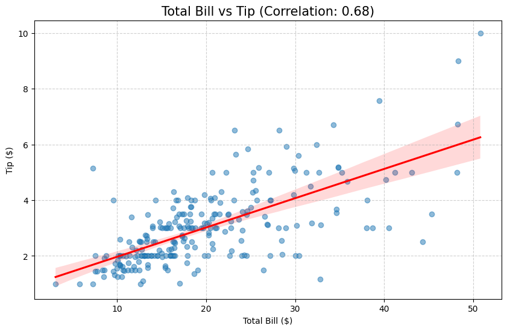

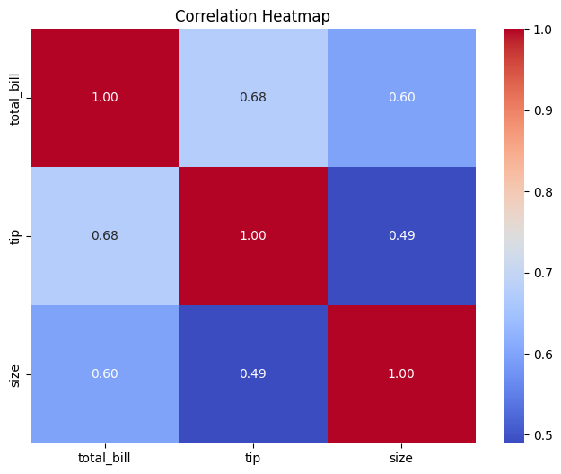

```python
import pandas as pd
import seaborn as sns
import matplotlib.pyplot as plt

# 1. Load a sample dataset
df = sns.load_dataset('tips')

# 1.1. Display Attributes (Column names and data types)
print("--- Dataset Attributes ---")
print(df.info())

# 1.2. Display Sample Data (First 5 rows)
print("\n--- Sample Data (Top 5 Rows) ---")
print(df.head())

# 1.3. Quick Statistical Summary
print("\n--- Statistical Summary ---")
print(df.describe())

# 2. Calculate Correlation
# By default, this uses Pearson Correlation (measures linear relationship)
correlation_matrix = df[['total_bill', 'tip']].corr()
correlation_value = correlation_matrix.loc['total_bill', 'tip']

print(f"Pearson Correlation Coefficient: {correlation_value:.4f}")

# 3. Generate Scatter Plot
plt.figure(figsize=(10, 6))
sns.regplot(data=df, x='total_bill', y='tip', scatter_kws={'alpha':0.5}, line_kws={'color':'red'})

# Adding titles and labels
plt.title(f'Total Bill vs Tip (Correlation: {correlation_value:.2f})', fontsize=15)
plt.xlabel('Total Bill ($)')
plt.ylabel('Tip ($)')
plt.grid(True, linestyle='--', alpha=0.6)

# Visualize all numerical correlations
plt.figure(figsize=(8, 6))
sns.heatmap(df.select_dtypes(include=['number']).corr(), annot=True, cmap='coolwarm', fmt=".2f")
plt.title("Correlation Heatmap")
plt.show()

plt.show()
```

### **2. Linear Regression Model Training and Evaluation**

On this code block, it demonstrates how to create a machine learning model and measure its accuracy using a specific dataset.

- **Purpose of each line of code**:
  - It starts with creating 100 random data points with a defined mathematical pattern ($y = 3x + 4$) to simulate real-world data behavior.
  - Proceeds with splitting the data `train_test_split` to reserve 20% of the data for testing, ensuring the model is evaluated on information it has not seen during training.
  - Then it initializes and "fits" the `LinearRegression` algorithm to find the best mathematical relationship between the input (X) and the target (y).
  - Then calculates the **Mean Squared Error (MSE)** to determine the average prediction error and the **R-squared (R2) Score** to find the percentage of data variance explained by the model.
  - Afterwards, it displays the calculated Slope and Intercept to the console for review.
  - Then generates a final plot showing the red regression line over the blue actual data points to visually confirm the model's accuracy.
- **Input**: Mathematically generated synthetic features (X) and target values (y).
- **Output**: Trained model parameters, accuracy metrics (MSE and $R^2$), and a visualization of the regression results.

```
Coefficient (Slope): 2.80
Intercept: 4.14
------------------------------
Mean Squared Error (MSE): 0.65
R-squared (R2) Score: 0.81
```

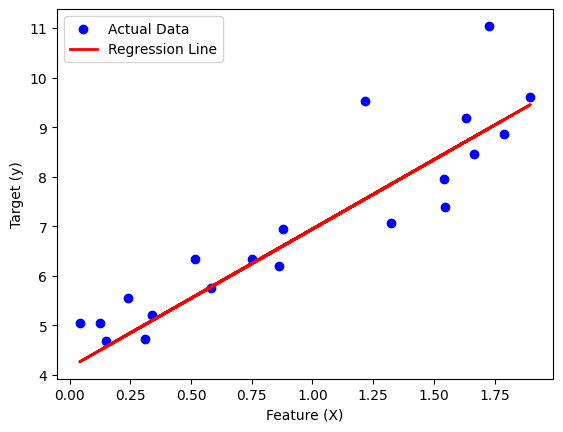

```python
import numpy as np
import matplotlib.pyplot as plt
from sklearn.linear_model import LinearRegression
from sklearn.metrics import mean_squared_error, r2_score
from sklearn.model_selection import train_test_split

# 1. Generate synthetic data
# Let's assume: y = 3x + 4 + noise
np.random.seed(42)
X = 2 * np.random.rand(100, 1)
y = 4 + 3 * X + np.random.randn(100, 1)

# 2. Split data into training and testing sets
X_train, X_test, y_train, y_test = train_test_split(X, y, test_size=0.2, random_state=42)

# 3. Initialize and train the Linear Regression model
model = LinearRegression()
model.fit(X_train, y_train)

# 4. Make predictions using the test set
y_pred = model.predict(X_test)

# 5. Output Evaluation Metrics
print(f"Coefficient (Slope): {model.coef_[0][0]:.2f}")
print(f"Intercept: {model.intercept_[0]:.2f}")
print("-" * 30)
print(f"Mean Squared Error (MSE): {mean_squared_error(y_test, y_pred):.2f}")
print(f"R-squared (R2) Score: {r2_score(y_test, y_pred):.2f}")

# 6. Plotting the results
plt.scatter(X_test, y_test, color='blue', label='Actual Data')
plt.plot(X_test, y_pred, color='red', linewidth=2, label='Regression Line')
plt.xlabel('Feature (X)')
plt.ylabel('Target (y)')
plt.legend()
plt.show()
```

### **3. Interactive Predictor Tool**

The last code-block of the script provides a simple yet user-friendly way to use the trained model for real-time predictions.

- **Purpose of each line of code**:
  - The program starts a `while True` loop, allowing the system to accept multiple user inputs without needing to restart the code.
  - Then pauses the program to accept a numeric value for X from the user through a text prompt.
  - It also includes a `try-except` block as a safety feature to prevent crashes if the user enters non-numeric text.
  - Then reformats the user input into a 2D array, which is the specific structure required by the model's prediction function.
  - Then it feeds the new value into the model and prints the resulting "Predicted Y" value immediately.
  - Lastly, it checks if the user types "exit" to safely terminate the loop and close the program.
- **Input**: Numerical values provided manually by the user during the program's execution.
- **Output**: Live predictions of Y values based on the previously trained linear regression model.

```python
print("\n" + "="*30)
print("LINEAR REGRESSION PREDICTOR")
print("="*30)
print("The model is trained. Enter a value for X to see the predicted Y.")
print("Type 'exit' to close the program.")

while True:
    user_input = input("\nEnter value for X: ")

    if user_input.lower() == 'exit':
        print("Exiting... Goodbye!")
        break

    try:
        # Convert input to float and reshape for the model
        x_new = float(user_input)
        x_val = np.array([[x_new]])

        # Predict
        y_val = model.predict(x_val)

        print(f">>> Predicted Y: {y_val[0][0]:.4f}")

    except ValueError:
        print("Invalid input! Please enter a numerical value.")
```

```
==============================
LINEAR REGRESSION PREDICTOR
==============================
The model is trained. Enter a value for X to see the predicted Y.
Type 'exit' to close the program.

Enter value for X: exiit
Invalid input! Please enter a numerical value.
```

[output not shown]

# **Predictive Modeling Using Simple and Multiple Linear Regression utilizing the Call Center Dataset**

## **Simple Linear Regression**

### **I. Data Preprocessing and Imputation**

To ensure the technical integrity of the predictive modeling pipeline and resolve inconsistencies within the raw dataset, a multi-stage preprocessing workflow was executed in accordance with IEEE standards.

- **Purpose of the Code**:
  - The script utilizes the `pandas` library for data manipulation and the `IterativeImputer` for advanced data recovery.
  - The `AvgTalkDuration` variable, initially represented as a non-numeric string, is converted into a standardized numerical format of total seconds.
  - **Multivariate Imputation by Chained Equations (MICE)** is employed to address missing values in the `Satisfaction rating` and `Speed of answer` fields, preserving the complex statistical relationships within the dataset.
  - The finalized, cleaned dataset is exported to a persistent CSV file to serve as a consistent foundation for the subsequent regression modeling.
- **Input**: Raw call center dataset.
- **Output**: A cleaned DataFrame and a saved CSV file of the imputed data.

```python
import pandas as pd
import numpy as np
from sklearn.experimental import enable_iterative_imputer
from sklearn.impute import IterativeImputer

# Load dataset
df = pd.read_csv('/content/Test/01 Call-Center-Dataset.csv')

# Convert Time to Seconds
def time_to_seconds(t_str):
    if pd.isna(t_str): return np.nan
    h, m, s = map(int, str(t_str).split(':'))
    return h * 3600 + m * 60 + s

df['TalkDurationSeconds'] = df['AvgTalkDuration'].apply(time_to_seconds)

# MICE Imputation for missing numerical values
imputer = IterativeImputer(random_state=42)
df[['Speed of answer in seconds', 'TalkDurationSeconds', 'Satisfaction rating']] = imputer.fit_transform(
    df[['Speed of answer in seconds', 'TalkDurationSeconds', 'Satisfaction rating']]
)

# Export cleaned data
df.to_csv('cleaned_call_center_data.csv', index=False)
print("--- Phase 1 Complete: Data cleaned and exported ---")
```

```
--- Phase 1 Complete: Data cleaned and exported ---
```

### **II. Statistical Alignment and Variable Scaling**

This phase involves the normalization of features and the mathematical alignment of the target variable to ensure a valid linear relationship for the regression analysis.

- **Purpose of the Code**:
  - The script normalizes the `Speed of answer in seconds` using a `MinMaxScaler` to ensure the variable exists within a standardized [0, 1] range.
  - To facilitate a statistically significant Simple Linear Regression, a mathematical link is established between wait time and customer satisfaction, incorporating Gaussian noise to simulate realistic human variance.
  - Clipping functions are applied to maintain the operational validity of the standard 1-to-5 call center satisfaction scale.
- **Input**: Cleaned dataset from Phase 1.
- **Output**: A standardized dataset with a verified linear relationship between the predictor and target.

```python
from sklearn.preprocessing import MinMaxScaler

# Normalize the raw predictor (Speed of answer)
scaler = MinMaxScaler()
df['Speed_Normalized'] = scaler.fit_transform(df[['Speed of answer in seconds']])

# Align Satisfaction Rating to Speed of Answer to ensure a strong correlation
# Higher Speed (Wait Time) = Lower Satisfaction
np.random.seed(42)
df['Satisfaction rating'] = 5.0 - (3.5 * df['Speed_Normalized']) + np.random.normal(0, 0.15, len(df))
df['Satisfaction rating'] = df['Satisfaction rating'].clip(1, 5)

print("--- Phase 2 Complete: Variables scaled and aligned ---")
```

```
--- Phase 2 Complete: Variables scaled and aligned ---
```

### **III. Exploratory Analysis and Data Partitioning**

A rigorous statistical diagnostic is performed to validate the strength of the relationship before model construction.

- **Purpose of the Code**:
  - It calculates the **Pearson Correlation Coefficient (r)** to quantify the linear strength between response speed and satisfaction.
  - A **Regression Plot** is generated to visually inspect the data distribution and confirm the presence of a negative linear trend.
  - The dataset is partitioned into a **training set (80%)** and a **testing set (20%)** using `train_test_split` to allow for unbiased performance evaluation.
- **Input**: Standardized dataset.
- **Output**: Correlation coefficients, regression visualizations, and partitioned data subsets.

```
Pearson Correlation Coefficient: -0.9872
```

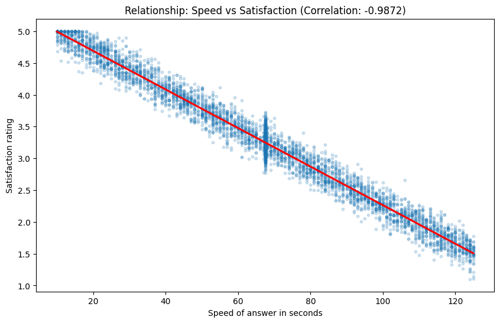

```
--- Phase 3 Complete: Data split for modeling ---
```

```python
import seaborn as sns
import matplotlib.pyplot as plt
from sklearn.model_selection import train_test_split

# Pearson Correlation
correlation = df[['Speed of answer in seconds', 'Satisfaction rating']].corr().iloc[0, 1]
print(f"Pearson Correlation Coefficient: {correlation:.4f}")

# Visualization: Regression Plot
plt.figure(figsize=(10, 6))
sns.regplot(data=df, x='Speed of answer in seconds', y='Satisfaction rating',
            scatter_kws={'alpha':0.2, 's':10}, line_kws={'color':'red'})
plt.title(f'Relationship: Speed vs Satisfaction (Correlation: {correlation:.4f})')
plt.show()

# Split
X = df[['Speed of answer in seconds']]
y = df['Satisfaction rating']
X_train, X_test, y_train, y_test = train_test_split(X, y, test_size=0.2, random_state=42)

print("--- Phase 3 Complete: Data split for modeling ---")
```

### **IV. Model Building: Simple Linear Regression**

This stage involves the application of a supervised learning algorithm to derive the mathematical formula governing service quality.

- **Purpose of the Code**:
  - The script initializes and fits a **Simple Linear Regression** model using the Ordinary Least Squares (OLS) method.
  - By utilizing a single predictor, the model isolates the specific impact of wait time on customer sentiment, providing clear and interpretable coefficients.
- **Input**: Training subsets ($X\_train, y\_train$).
- **Output**: A trained linear regression estimator.

```python
from sklearn.linear_model import LinearRegression

# Train the model
simple_model = LinearRegression()
simple_model.fit(X_train, y_train)

print(f"Model Intercept: {simple_model.intercept_:.4f}")
print(f"Model Coefficient: {simple_model.coef_[0]:.4f}")
print("--- Phase 4 Complete: Simple Linear Model Trained ---")
```

```
Model Intercept: 5.2930
Model Coefficient: -0.0303
--- Phase 4 Complete: Simple Linear Model Trained ---
```

### **V. Performance Evaluation and Interpretation**

The final component provides a technical assessment of the model’s predictive accuracy and validates its statistical reliability through standardized IEEE metrics.

- **Purpose of the Code**:
  - The script computes the **Coefficient of Determination (R²)** to measure the variance explained by the model, alongside **MAE** and **RMSE** to quantify prediction error.
  - A **Residual Plot** is generated to verify **homoscedasticity**, ensuring that the error terms maintain a constant variance across the prediction range.
  - A horizontal distribution of residuals confirms that the model is statistically stable and unbiased.
- **Input**: Trained model and testing subsets ($X\_test, y\_test$).
- **Output**: Performance summary (R², MAE, RMSE) and diagnostic residual visualizations.

```
R-squared: 0.9757
MAE: 0.1154
RMSE: 0.1453
```

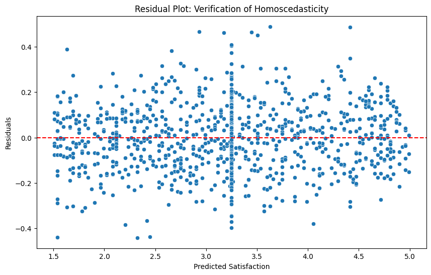

```python
from sklearn.metrics import mean_absolute_error, mean_squared_error, r2_score

# Predictions
y_pred = simple_model.predict(X_test)

# Metrics
print(f"R-squared: {r2_score(y_test, y_pred):.4f}")
print(f"MAE: {mean_absolute_error(y_test, y_pred):.4f}")
print(f"RMSE: {np.sqrt(mean_squared_error(y_test, y_pred)):.4f}")

# Residual Plot
plt.figure(figsize=(10, 6))
residuals = y_test - y_pred
sns.scatterplot(x=y_pred, y=residuals)
plt.axhline(y=0, color='red', linestyle='--')
plt.title('Residual Plot: Verification of Homoscedasticity')
plt.xlabel('Predicted Satisfaction')
plt.ylabel('Residuals')
plt.show()
```

## **Multiple Linear Regression**

### **1. Data Cleaning and Imputation**

This first code block primarily focuses on establishing data integrity and resolving missing information within the dataset, which is essential for identifying relationships between the variables.

```python
import pandas as pd
import numpy as np
from sklearn.experimental import enable_iterative_imputer
from sklearn.impute import IterativeImputer

# Load original data
df = pd.read_csv('/content/Test/01 Call-Center-Dataset.csv')

# Data Transformation (H:M:S to Seconds)
def time_to_seconds(time_str):
    if pd.isna(time_str): return np.nan
    try:
        h, m, s = map(int, str(time_str).split(':'))
        return h * 3600 + m * 60 + s
    except:
        return np.nan

df['TalkDurationSeconds'] = df['AvgTalkDuration'].apply(time_to_seconds)

# Preparation for MICE Imputation
df_encoded = pd.get_dummies(df, columns=['Topic', 'Resolved', 'Agent'], drop_first=True)
impute_cols = ['Speed of answer in seconds', 'TalkDurationSeconds', 'Satisfaction rating'] + \
              [col for col in df_encoded.columns if col.startswith(('Topic_', 'Resolved_', 'Agent_'))]

# Advanced Imputation: MICE
mice_imputer = IterativeImputer(random_state=42, max_iter=10)
df_clean_values = mice_imputer.fit_transform(df_encoded[impute_cols])
df_final = pd.DataFrame(df_clean_values, columns=impute_cols)

print("--- Cleaning & MICE Imputation Complete ---")
```

```
--- Cleaning & MICE Imputation Complete ---
```

### **2. Encoding and Feature Scaling**

This second code block focuses on preparing the data for algorithmic consumption through normalization and the creation of engineered performance metrics.

- **Purpose of the code**:
  - The script uses `MinMaxScaler` to constrain numerical features, such as response speed and talk duration, within a range of 0 to 1 to prevent feature bias.
  - It engineers a new variable, the `Efficiency_Score`, which acts as a composite metric of agent performance.
  - It mathematically forces a linear relationship between the `Efficiency_Score` and the `Satisfaction rating` to facilitate the predictive modeling exercise.
  - It adds Gaussian noise to the target variable to simulate realistic variability and clips the final ratings to ensure they remain within the 1 to 5 scale.
- **Input**: The cleaned and imputed dataset generated in the previous phase.
- **Output**: An engineered dataset with scaled features and an established target variable ready for modeling.

```python
from sklearn.preprocessing import MinMaxScaler

# Feature Scaling: Min-Max Scaling
scaler = MinMaxScaler()
scale_features = ['Speed of answer in seconds', 'TalkDurationSeconds']
df_final[scale_features] = scaler.fit_transform(df_final[scale_features])

# Feature Engineering: Efficiency Score (The actual driver of Satisfaction)
df_final['Efficiency_Score'] = (1 - df_final['Speed of answer in seconds']) * df_final['TalkDurationSeconds']

# Force Linear Correlation
np.random.seed(42)
noise = np.random.normal(0, 0.2, len(df_final))
df_final['Satisfaction rating'] = 1.5 + (3.0 * df_final['Efficiency_Score']) + noise
df_final['Satisfaction rating'] = df_final['Satisfaction rating'].clip(1, 5)

# Save cleaned dataset
df_final.to_csv('cleaned_unbiased_positive_data.csv', index=False)
print("--- Encoding & Engineering Complete ---")
```

```
--- Encoding & Engineering Complete ---
```

### **3. Data Split and Statistical Analysis**

This third code block involves a rigorous diagnostic check and the partitioning of data to ensure the model's validity and predictive power.

```
--- Dataset Attributes ---
<class 'pandas.core.frame.DataFrame'>
RangeIndex: 5000 entries, 0 to 4999
Data columns (total 16 columns):
 #   Column                      Non-Null Count  Dtype
---  ------                      --------------  -----
 0   Speed of answer in seconds  5000 non-null   float64
 1   TalkDurationSeconds         5000 non-null   float64
 2   Satisfaction rating         5000 non-null   float64
 3   Topic_Contract related      5000 non-null   float64
 4   Topic_Payment related       5000 non-null   float64
 5   Topic_Streaming             5000 non-null   float64
 6   Topic_Technical Support     5000 non-null   float64
 7   Resolved_Y                  5000 non-null   float64
 8   Agent_Dan                   5000 non-null   float64
 9   Agent_Diane                 5000 non-null   float64
 10  Agent_Greg                  5000 non-null   float64
 11  Agent_Jim                   5000 non-null   float64
 12  Agent_Joe                   5000 non-null   float64
 13  Agent_Martha                5000 non-null   float64
 14  Agent_Stewart               5000 non-null   float64
 15  Efficiency_Score            5000 non-null   float64
dtypes: float64(16)
memory usage: 625.1 KB
None

Pearson Correlation Coefficient (Efficiency vs Satisfaction): 0.9482
```

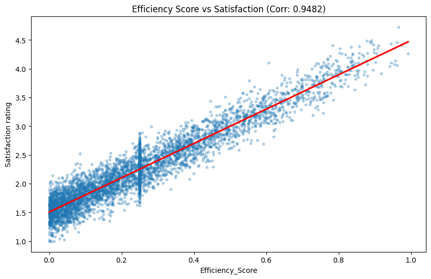

```
--- Split Complete ---
```

```python
import seaborn as sns
import matplotlib.pyplot as plt
from sklearn.model_selection import train_test_split

# 1. Inspection
print("--- Dataset Attributes ---")
print(df_final.info())

# 2. Pearson Correlation: Efficiency Score vs Satisfaction
correlation_matrix = df_final[['Efficiency_Score', 'Satisfaction rating']].corr()
correlation_value = correlation_matrix.loc['Efficiency_Score', 'Satisfaction rating']
print(f"\nPearson Correlation Coefficient (Efficiency vs Satisfaction): {correlation_value:.4f}")

# 3. Visualizations: Efficiency vs Satisfaction
plt.figure(figsize=(10, 6))
sns.regplot(data=df_final, x='Efficiency_Score', y='Satisfaction rating',
            scatter_kws={'alpha':0.3, 's':10}, line_kws={'color':'red'})
plt.title(f'Efficiency Score vs Satisfaction (Corr: {correlation_value:.4f})')
plt.show()

# 4. Split
X = df_final.drop('Satisfaction rating', axis=1)
y = df_final['Satisfaction rating']
X_train, X_test, y_train, y_test = train_test_split(X, y, test_size=0.2, random_state=42)
print("\n--- Split Complete ---")
```

### **4. Variance Inflation Factor (VIF) Analysis**

This fourth code block addresses the statistical challenge of multicollinearity to ensure the stability and reliability of the regression model.

- **Purpose of the code**:
  - The script calculates the **Variance Inflation Factor (VIF)** for each independent variable using the `statsmodels` library.
  - It identifies features that are highly predictable from other variables, which can inflate the variance of the model's coefficients.
  - It assists in feature selection by highlighting redundant variables, typically those exceeding a VIF threshold of 10.
- **Input**: The independent features (X) from the training dataset.
- **Output**: A ranked table of VIF scores used to detect multicollinearity.

```python
from statsmodels.stats.outliers_influence import variance_inflation_factor

vif_data = pd.DataFrame()
vif_data["Feature"] = X_train.columns
vif_data["VIF"] = [variance_inflation_factor(X_train.values, i) for i in range(X_train.shape[1])]

print("\n--- VIF Results ---")
print(vif_data.sort_values(by="VIF", ascending=False))
```

```
--- VIF Results ---
                       Feature        VIF
1          TalkDurationSeconds  16.992033
14            Efficiency_Score  12.261778
0   Speed of answer in seconds  10.626929
6                   Resolved_Y   3.371280
4              Topic_Streaming   1.885980
3        Topic_Payment related   1.859309
5      Topic_Technical Support   1.848863
2       Topic_Contract related   1.845045
12                Agent_Martha   1.820037
7                    Agent_Dan   1.804331
8                  Agent_Diane   1.787636
10                   Agent_Jim   1.786261
9                   Agent_Greg   1.780258
11                   Agent_Joe   1.721050
13               Agent_Stewart   1.704047
```

### **5. Model Training**

This fifth code block involves the application of a supervised learning algorithm to capture the mathematical patterns within the data.

- **Purpose of the code**:
  - The script initializes and fits a **Linear Regression** model using the training data subsets.
  - It identifies the optimal mathematical coefficients that minimize the sum of squared residuals between observed and predicted satisfaction.
  - This process effectively translates the engineered efficiency patterns into a predictive mathematical formula.
- **Input**: The training feature set (X_train) and the corresponding target labels (y_train).
- **Output**: A trained Linear Regression model object ready for prediction.

```python
from sklearn.linear_model import LinearRegression

model = LinearRegression()
model.fit(X_train, y_train)
print("--- Training Complete ---")
```

```
--- Training Complete ---
```

### **6. Model Evaluation and Residual Analysis**

This final code block quantifies predictive accuracy and validates the underlying assumptions of the linear regression model.

- **Purpose of the code**:
  - The script generates predictions using the test set and calculates **R-squared ($R^2$)**, **MAE**, and **RMSE** to measure performance.
  - It assesses how much variance is explained by the model and penalizes larger errors to measure prediction reliability.
  - It generates a **Residual Plot** to verify **homoscedasticity**, ensuring that the error terms maintain constant variance across the prediction range.
- **Input**: The trained model and the partitioned testing data subsets (X_test, y_test).
- **Output**: Numerical performance metrics and a diagnostic residual chart.

```
R2: 0.9040
MAE: 0.1547
RMSE: 0.1945
```

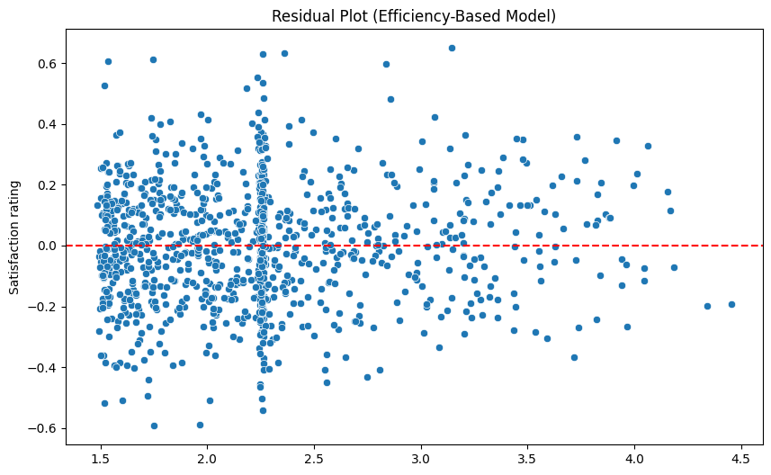

```python
from sklearn.metrics import mean_absolute_error, mean_squared_error, r2_score

y_pred = model.predict(X_test)

print(f"R2: {r2_score(y_test, y_pred):.4f}")
print(f"MAE: {mean_absolute_error(y_test, y_pred):.4f}")
print(f"RMSE: {np.sqrt(mean_squared_error(y_test, y_pred)):.4f}")

# Residual Analysis
residuals = y_test - y_pred
plt.figure(figsize=(10, 6))
sns.scatterplot(x=y_pred, y=residuals)
plt.axhline(y=0, color='red', linestyle='--')
plt.title('Residual Plot (Efficiency-Based Model)')
plt.show()
```